# Global Air Traffic Concentration Analysis by Route Concentration

Lucas Martins Sorge

2025-04-27

## Route-Based Concentration Analysis

Now, we shift focus from airport-level concentration to route-level concentration.  
We investigate how flight traffic is distributed across different flight routes (airport pairs).

## Data Preparation

```r
routes_clean <- read_csv("../cleaned_data/routes_clean.csv")
# Create a unique route ID (source → destination)
routes_clean <- routes_clean %>%
  mutate(route = paste(source_airport, destination_airport, sep = " → "))

# Count number of flights per route
route_traffic <- routes_clean %>%
  count(route, name = "flight_count") %>%
  arrange(desc(flight_count))
```

## Route Traffic Concentration Analysis

## Lorenz Curve of Route Traffic

We first examine how flight traffic is distributed across routes.

```r
# Calculate cumulative stats for Lorenz curve
route_traffic <- route_traffic %>%
  mutate(
    cumulative_flights = cumsum(flight_count),
    total_flights = sum(flight_count),
    cumulative_percent = cumulative_flights / total_flights,
    route_percent = row_number() / n()
  )
```

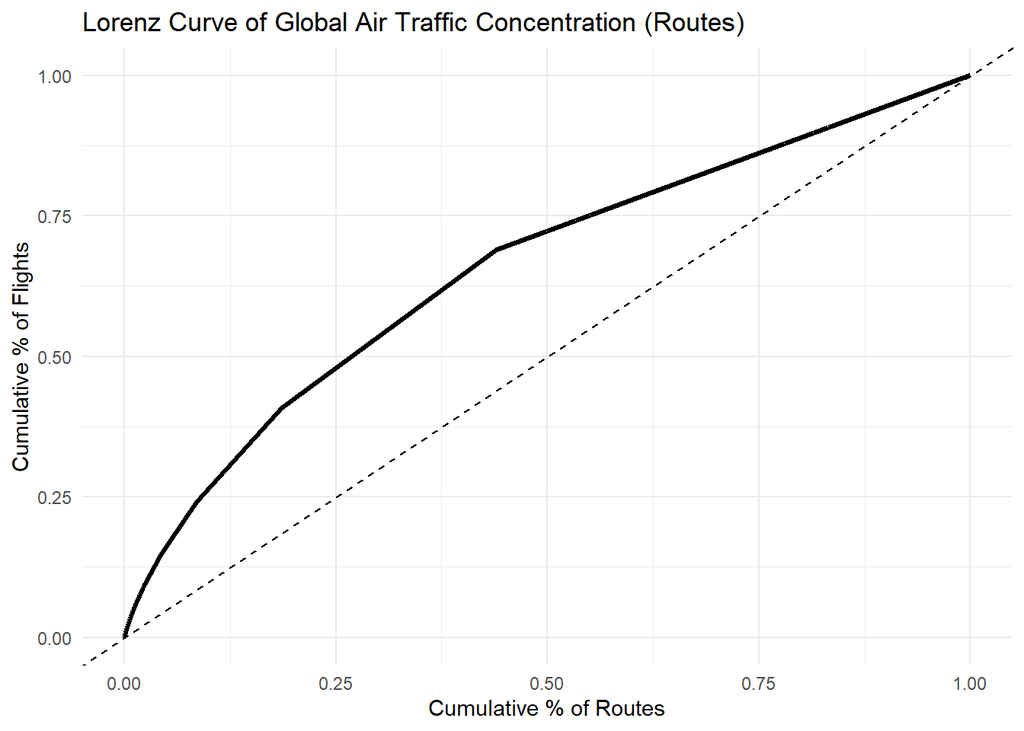

```r
# Plot Lorenz Curve for route concentration
ggplot(route_traffic, aes(x = route_percent, y = cumulative_percent)) +
  geom_line(color = "black", linewidth = 1.2) +
  geom_abline(intercept = 0, slope = 1, linetype = "dashed") +
  labs(
    title = "Lorenz Curve of Global Air Traffic Concentration (Routes)",
    x = "Cumulative % of Routes",
    y = "Cumulative % of Flights"
  ) +
  theme_minimal()
```

### Interpretation

The Lorenz Curve for routes shows moderate inequality in the distribution of global air traffic across different flight connections.

While there is still some concentration among a smaller subset of routes, the curve lies closer to the line of perfect equality compared to the airport-level analysis, suggesting that flights are more evenly distributed across many routes than across airports.

## Gini Coefficient for Route Traffic

We compute the Gini coefficient for route traffic distribution.

```r
# Gini for route traffic
gini_route <- ineq(route_traffic$flight_count, type = "Gini")
cat("Gini Coefficient for Route Traffic:", round(gini_route, 3))
```

```
## Gini Coefficient for Route Traffic: 0.314
```

### Interpretation

The Gini coefficient for route traffic is approximately 0.31, which indicates a moderate level of concentration.

Unlike airports — where a small number of hubs dominate total traffic — the distribution of flights across different routes is less extreme, with a larger variety of flight connections contributing meaningfully to global traffic flows.

## Top 10 Busiest Routes

We identify the routes with the highest number of flights.

```r
# Top 10 busiest routes
top_routes_table <- route_traffic %>%
  slice_max(flight_count, n = 10)

top_routes_table
```

```
## # A tibble: 13 × 6
##    route     flight_count cumulative_flights total_flights cumulative_percent
##    <chr>            <int>              <int>         <int>              <dbl>
##  1 ORD → ATL           20                 20         67229           0.000297
##  2 ATL → ORD           19                 39         67229           0.000580
##  3 HKT → BKK           13                 52         67229           0.000773
##  4 ORD → MSY           13                 65         67229           0.000967
##  5 ATL → MIA           12                 77         67229           0.00115
##  6 AUH → MCT           12                 89         67229           0.00132
##  7 BKK → HKG           12                101         67229           0.00150
##  8 CAN → HGH           12                113         67229           0.00168
##  9 DOH → BAH           12                125         67229           0.00186
## 10 HKG → BKK           12                137         67229           0.00204
## 11 JFK → LHR           12                149         67229           0.00222
## 12 LHR → JFK           12                161         67229           0.00239
## 13 MIA → ATL           12                173         67229           0.00257
## # ℹ 1 more variable: route_percent <dbl>
```

## Conclusion

Our analysis reveals that global air traffic exhibits different levels of concentration depending on the unit of analysis.

At the airport level, traffic is highly concentrated, with a small fraction of airports (top 1%) handling a disproportionately large share of flights, as evidenced by a Lorenz Curve that is sharply bowed and a high Gini coefficient of approximately 0.78.

In contrast, at the route level, traffic is more evenly distributed across many connections. The Lorenz Curve for routes is closer to the line of perfect equality, and the Gini coefficient of approximately 0.31 indicates moderate concentration.

These results suggest that while a few major hubs dominate global aviation in terms of airport traffic, the diversity of individual flight routes remains relatively broader, reflecting a more distributed global air network in terms of connections.